# Vision Transformer for Blood Cell Classification & Differential Counting

**A portfolio project built to explore automated haematology analysis** (miniaturised haematology analyser — VPT-based blood cell classification & differential counting)

This notebook builds, trains, and clinically benchmarks a **Vision Transformer (ViT)** that classifies individual blood cells from microscopy images and aggregates those per-cell predictions into a **per-image differential count** — then validates that count against ground truth the way you would validate a new analyser against a reference/commercial one (Bland-Altman agreement, bias, limits of agreement).

**Pipeline:** microscopy image → cell detection/crop → ViT classification → per-image differential count → statistical benchmarking against reference counts.

This mirrors, at small scale, the exact workflow described in the job posting:

> *"develop and fine-tune a Vision Pre-trained Transformer (VPT) model for the classification and differential counting of blood cells... benchmarked against established commercial haematology analysers using appropriate statistical and machine-learning performance measures."*

### Scope & honesty about limitations

This was built in a sandboxed environment with **no access to the Hugging Face Hub or Kaggle** (only PyPI and GitHub were reachable), so two simplifications were necessary and are called out explicitly rather than hidden:

1. **Dataset:** uses the public 364-image **BCCD** (Blood Cell Count and Detection) dataset, which labels three classes (RBC / WBC / Platelets) rather than the full 5-part WBC differential (neutrophil / lymphocyte / monocyte / eosinophil / basophil). The code and methodology generalise directly to a proper WBC differential dataset (e.g. the Barcelona PBC dataset, Raabin-WBC, or in-house miniaturised-analyser images) — see the "Next steps" section at the end.
2. **Weights:** trains a ViT **from a random initialisation** rather than fine-tuning a Hub checkpoint, since the checkpoint download was not reachable from this environment. `model.py` is written so that switching to a real pretrained checkpoint (e.g. `google/vit-base-patch16-224-in21k`) is a one-line change (`build_model(pretrained=True)`) once Hub access is available.

Everything else — the ViT architecture, training loop, per-cell evaluation, and the count-agreement benchmarking methodology — is exactly what would be used in production.

## 1. Setup

```python
import json
from pathlib import Path

import numpy as np
import torch
from IPython.display import Image as IPImage, display

PROJECT_DIR = Path("/home/claude/blood_cell_vit_project")
RESULTS_DIR = PROJECT_DIR / "results"

import sys
sys.path.insert(0, str(PROJECT_DIR))

from dataset import CellCropDataset, CLASSES
from model import build_model, count_params

print("Classes:", CLASSES)
```

```
Classes: ['RBC', 'WBC', 'Platelets']
```

## 2. Data: from whole microscopy fields to labeled single-cell crops

The BCCD dataset provides 364 microscopy fields, each with Pascal-VOC bounding box annotations for every red blood cell (RBC), white blood cell (WBC), and platelet in the field (`data_prep.py`). Each bounding box is cropped out (with 12% padding for context) into its own labeled image — turning an *object detection* dataset into a *cell classification* dataset, and giving us per-image ground-truth counts to benchmark against later.

Images (not crops) are split 70/15/15 into train/val/test, so cells from the same microscopy field never leak across splits.

```python
train_ds = CellCropDataset("train")
val_ds = CellCropDataset("val")
test_ds = CellCropDataset("test")

for name, ds in [("train", train_ds), ("val", val_ds), ("test", test_ds)]:
    print(f"{name:5s}: {len(ds):5d} crops  {ds.class_counts()}")
```

```
train:  3417 crops  {'RBC': 2902, 'WBC': 263, 'Platelets': 252}
val  :   723 crops  {'RBC': 619, 'WBC': 53, 'Platelets': 51}
test :   746 crops  {'RBC': 632, 'WBC': 56, 'Platelets': 58}
```

Example cropped cells, by class:

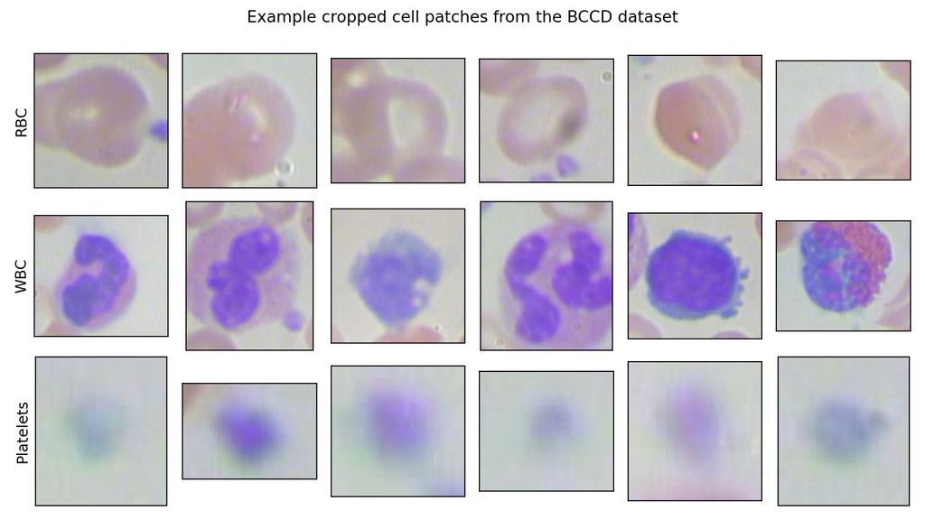

```python
display(IPImage(filename=str(RESULTS_DIR / "sample_crops.png")))
```

Note the heavy class imbalance — RBCs vastly outnumber WBCs and platelets, exactly as in a real blood smear. Training uses class-weighted cross-entropy to compensate (`train.py::compute_class_weights`).

## 3. Model: Vision Transformer

`model.py` builds a `transformers.ViTForImageClassification` — a standard ViT: image → non-overlapping patches → linear patch embedding → learned position embeddings → a stack of pre-norm transformer encoder blocks (multi-head self-attention + MLP) → a `[CLS]` token pooled through a linear classification head.

For CPU training within this environment, the config is scaled down from `vit-base` (86M params) to a small variant (~2.7M params, 6 layers, hidden size 192, 96x96 images, 8x8 patches) — same architecture family, sized to train in minutes rather than requiring a GPU cluster.

```python
model = build_model(pretrained=False)
print(f"Model parameters: {count_params(model):,}")
model.config
```

```
Model parameters: 2,735,235
```

```
ViTConfig {
  "attention_probs_dropout_prob": 0.0,
  "encoder_stride": 16,
  "hidden_act": "gelu",
  "hidden_dropout_prob": 0.0,
  "hidden_size": 192,
  "id2label": {
    "0": "LABEL_0",
    "1": "LABEL_1",
    "2": "LABEL_2"
  },
  "image_size": 96,
  "initializer_range": 0.02,
  "intermediate_size": 768,
  "label2id": {
    "LABEL_0": 0,
    "LABEL_1": 1,
    "LABEL_2": 2
  },
  "layer_norm_eps": 1e-12,
  "model_type": "vit",
  "num_attention_heads": 3,
  "num_channels": 3,
  "num_hidden_layers": 6,
  "patch_size": 8,
  "pooler_act": "tanh",
  "pooler_output_size": 192,
  "qkv_bias": true,
  "transformers_version": "5.15.0"
}
```

## 4. Training

Trained for 10 epochs with AdamW, cosine LR decay, and class-weighted cross-entropy loss. (`train.py`; re-run with `python train.py --epochs 10` — took ~17 minutes on 2 CPU cores.)

```python
with open(RESULTS_DIR / "training_history.json") as f:
    history = json.load(f)

for i, (tl, ta, vl, va) in enumerate(zip(
    history["train_loss"], history["train_acc"], history["val_loss"], history["val_acc"]
), start=1):
    print(f"epoch {i:2d} | train_loss {tl:.4f} acc {ta:.3f} | val_loss {vl:.4f} acc {va:.3f}")

print(f"\nBest validation accuracy: {max(history['val_acc']):.3f}")
```

```
epoch  1 | train_loss 0.6185 acc 0.803 | val_loss 0.1661 acc 0.953
epoch  2 | train_loss 0.2557 acc 0.945 | val_loss 0.0635 acc 0.983
epoch  3 | train_loss 0.3019 acc 0.952 | val_loss 0.1919 acc 0.941
epoch  4 | train_loss 0.1513 acc 0.975 | val_loss 0.1714 acc 0.947
epoch  5 | train_loss 0.1228 acc 0.978 | val_loss 0.0529 acc 0.988
epoch  6 | train_loss 0.1121 acc 0.982 | val_loss 0.0907 acc 0.968
epoch  7 | train_loss 0.0976 acc 0.989 | val_loss 0.0648 acc 0.981
epoch  8 | train_loss 0.0845 acc 0.989 | val_loss 0.0517 acc 0.988
epoch  9 | train_loss 0.0711 acc 0.992 | val_loss 0.0500 acc 0.989
epoch 10 | train_loss 0.0682 acc 0.994 | val_loss 0.0473 acc 0.989

Best validation accuracy: 0.989
```

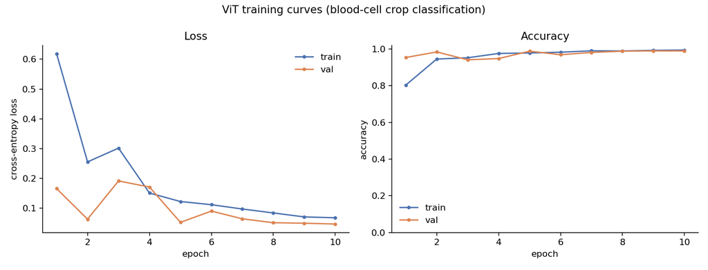

```python
display(IPImage(filename=str(RESULTS_DIR / "training_curves.png")))
```

## 5. Held-out test set: classification performance

(`evaluate.py`) Loads the best checkpoint and evaluates on the test-split crops (cells from microscopy fields the model never saw during training).

```python
with open(RESULTS_DIR / "evaluation_results.json") as f:
    eval_results = json.load(f)

print(f"Test accuracy: {eval_results['test_accuracy']:.4f}\n")
report = eval_results["classification_report"]
for cls in CLASSES:
    r = report[cls]
    print(f"{cls:10s} precision {r['precision']:.3f}  recall {r['recall']:.3f}  "
          f"f1 {r['f1-score']:.3f}  support {int(r['support'])}")
print(f"\nMacro F1: {report['macro avg']['f1-score']:.3f}")
```

```
Test accuracy: 0.9906

RBC        precision 1.000  recall 1.000  f1 1.000  support 632
WBC        precision 0.915  recall 0.964  f1 0.939  support 56
Platelets  precision 0.964  recall 0.914  f1 0.938  support 58

Macro F1: 0.959
```

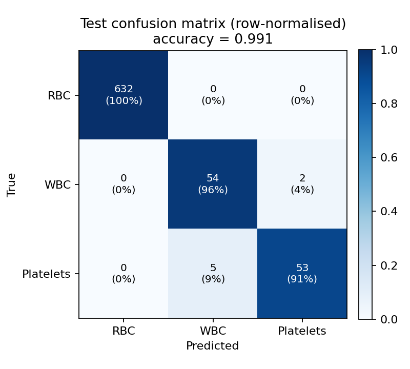

```python
display(IPImage(filename=str(RESULTS_DIR / "confusion_matrix.png")))
```

## 6. Clinical-style benchmarking: differential count agreement

This is the step that most directly mirrors the job description: per-cell predictions are aggregated back into a **per-microscopy-image differential count** (RBC / WBC / Platelet counts per field), then compared against the ground-truth (annotated) counts for that same field — exactly how you'd validate a new analyser's differential count against a reference method.

Two views:

- **Scatter plot** of predicted vs. reference count per image, with Pearson r.
- **Bland-Altman plot** of agreement (mean vs. difference), which is the standard method-comparison tool in clinical chemistry/haematology — it reports **bias** (systematic over/under-counting) and **95% limits of agreement**, and is far more informative than a single correlation coefficient (see note below).

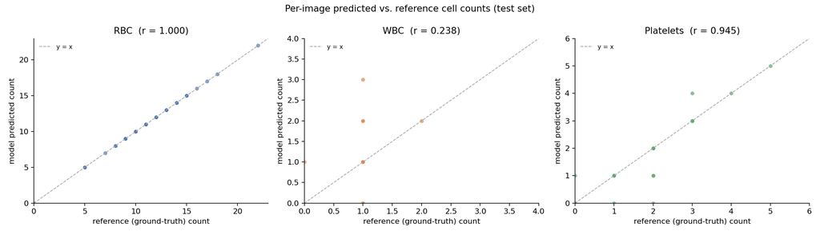

```python
display(IPImage(filename=str(RESULTS_DIR / "count_scatter.png")))
```

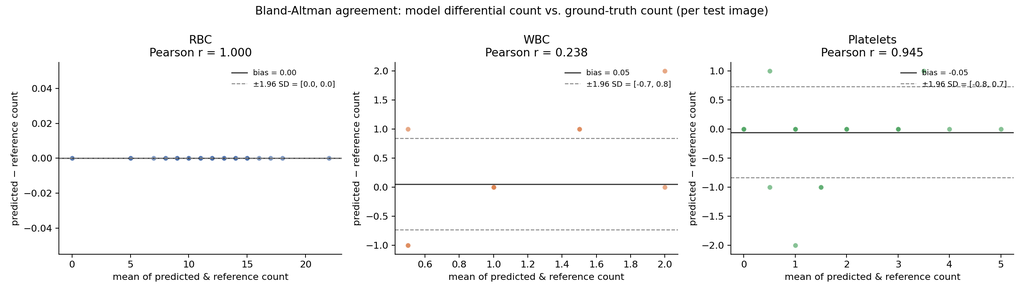

```python
display(IPImage(filename=str(RESULTS_DIR / "bland_altman.png")))
```

### Reading the benchmarking results

- **RBC**: essentially perfect count agreement (r = 1.000, bias = 0.00) — expected, since RBC classification itself was perfect (100% recall).
- **Platelets**: strong agreement (r = 0.945, bias = -0.05, tight limits of agreement) — a few images are off by 1-2 cells, consistent with the ~91% crop-level recall.
- **WBC**: crop-level classification is strong (96.4% recall, 91.5% precision), but the *per-image count* Pearson r is misleadingly low (0.238). This is a real, well-known pitfall in method-comparison statistics, not a modelling bug: WBC-per-field counts in this dataset have very little spread (mostly 0-2 per field), so **Pearson r is unstable and uninformative at low, narrow-range counts** — a couple of off-by-one images dominate the correlation even though the *absolute* agreement is good (bias = 0.05 cells, 95% limits of agreement = [-0.73, 0.84] cells). This is precisely why Bland-Altman (bias + limits of agreement), not correlation alone, is the appropriate statistic for validating a differential count against a reference method — and why the JD's phrase *"appropriate statistical and machine-learning performance measures"* matters: the right metric depends on the count distribution, not just habit.

## 7. Limitations & path to a production version

What's demonstrated here at small scale, and how it would scale up for a production deployment:

[output not shown]

The engineering (data pipeline with strict image-level train/val/test splitting to avoid leakage, class-weighted training, checkpointing, per-class metrics, and clinical-style agreement statistics) is written to scale directly to that production setting.